# Data Analyst Job Market: Salary, Experience, and Tools

Buntubethu Malunga Workshop 3

May 27, 2026

## Introduction

This report explores a **sample of 400 data analyst job postings**, focusing on estimated median salary, stated minimum years of experience, and whether postings mention **R**, **Python**, both, or neither. Salaries are employer or platform estimates (USD) and experience requirements were extracted from job text, so some values are missing or unreliable.

The sample is useful for exploration but **not representative of the full job market**: with only 400 listings, patterns can shift easily if a few high- or low-paying roles are added or removed. Interpret the plots below as descriptive snapshots, not definitive conclusions.

## Experience and salary

Among postings with a numeric minimum experience requirement, **308** rows have both experience and salary available (others were coded as missing or could not be parsed).

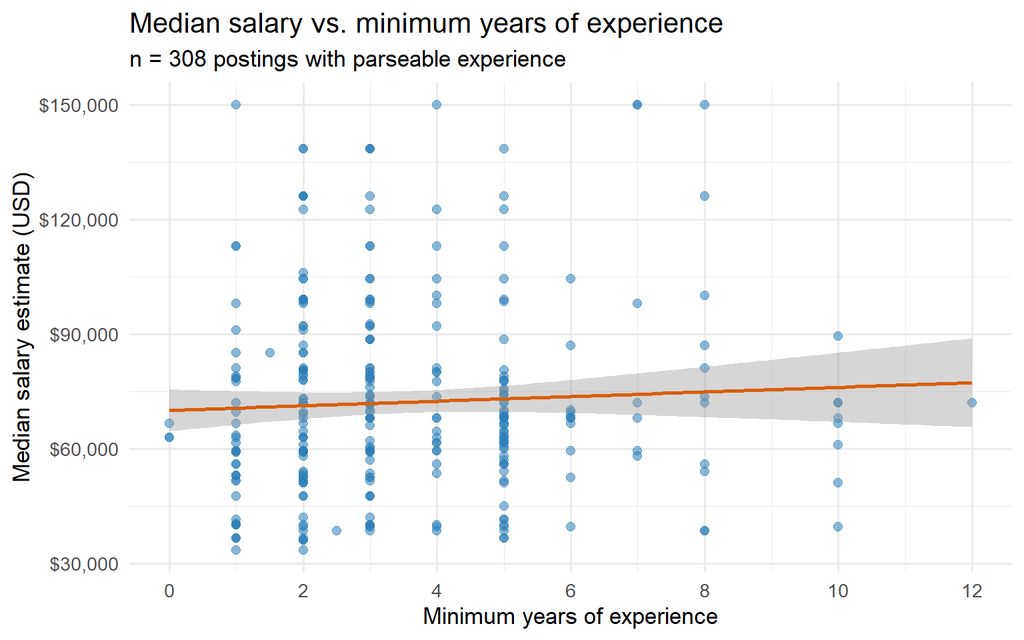

**Interpretation.** The scatter plot shows whether higher stated experience requirements tend to accompany higher estimated salaries. A fitted trend line summarizes the average direction in this sample; individual points spread widely, which is typical when role level, industry, and location vary. Many postings lack a usable experience field (92 excluded here), so the plot under-represents the full sample. With only 308 complete pairs, the trend is sensitive to outliers and should be read cautiously.

## Salary by data language

The **Data Languages** field classifies whether each posting mentions R, Python, both, or neither (based on text extraction).

| Data languages | Postings | Share of sample |
| --- | --- | --- |
| R | 15 | 3.8% |
| Python | 61 | 15.2% |
| Both | 69 | 17.2% |
| Neither | 255 | 63.7% |

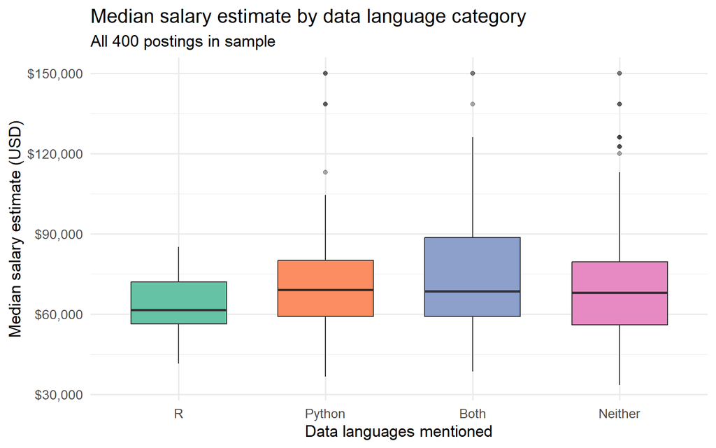

**Interpretation.** Box plots compare the distribution of salary estimates across language categories. Medians and spreads differ, but group sizes are uneven (for example, fewer postings mention R alone than “Neither”), so apparent gaps may reflect sampling noise rather than a true pay premium. Salary estimates also mix roles, seniority, and geography. Treat differences as hypotheses to test on a larger, more complete dataset—not as proof that learning a given language guarantees higher pay.

## Personal reflection

I had difficulties in the beginning with the pre-work and the key, but after starting all over again, l then realised that The Graph Network had sent the API key already. Using LLMs especially for sentiment analysis will most likely be fun and exciting and helps to decode and understand the data better especially since l work with a lot of survey data. Looking forward to applying this in my workplace. Regarding use of the credits and tokens, l am worried about the budget and how much one would spend in order to process and make use of this tool.